# Algorithm Class 13 - Practice 8

Binary Trees - II

June/10/2019

# 1 Delete in BST

```
  3                              3
 / \                            / \
2   8      delete(root, 8)     2  10
   / \       ---------->          / \
  6  10                          6  12
       \
       12
```

- Step 1: Find the node to be deleted. - trivial?
- Step 2: Delete it. - not trivial? how many possible situations?

Case 1. The node to be deleted has no children.

```
target == 8
  3          3
 / \  --->  /
2   8      2
```

Case 2. The node to be deleted has no left child.

```
target == 8
  3              3
 / \            / \
2   8   --->   2  10
     \
     10
```

Case 3. The node to be deleted has no right child.

```
target == 8
  3              3
 / \            / \
2   8   --->   2   6
   /
  6
```

Case 4. The node to be deleted has both left and right child. We need to move some nodes from left/right subtree to replace it.

- Which node to replace 8?
  - either from left sub, largest of the left subtree
  - or from right sub, smallest of the right subtree

Case 4.1. node.right does not have left child, meaning itself is the smallest node in this case, we just move node.right up.

```
  3              3
 / \            / \
2   8   --->   2  10
   / \            / \
  6  10          6  12
       \
       12

root -> 8
root.right -> 10
root.right.left -> null
root.right.left = root.left
```

Case 4.2. node.right has left child, we need to find the smallest node, and move it up.

```
  3              3
 / \            / \
2   8   --->   2   9
   / \            / \
  6  12          6  12
    /  \           /  \
   11  14         11  14
  /              /
 9              10
  \
   10

12 -> left -> left -> left
9.left == null

return: the node that replaces target
```

```java
public TreeNode delete(TreeNode root, int target) {
  if (root == null) {
    return null;
  }
  // Find target node
  if (root.val > target) {
    root.left = delete(root.left, target);
    return root;
  }
  else if (root.val < target) {
    root.right = delete(root.right, target);
    return root;
  }
  // Guarantee root != null && root.val == target
  if (root.left == null) {  // Case 1, 2
    return root.right;
  }
  else if (root.right == null) {  // Case 3
    return root.left;
  }

  // Guarantee root.left != null && root.right != null
  // Case 4.1
  if (root.right.left == null) {
    root.right.left = root.left;
    return root.right;
  }
  // Case 4.2
  // 1. Find and delete smallest node in root.right.
  TreeNode smallest = deleteSmallest(root.right);
  // 2. Connect the smallest node with root.left and root.right.
  smallest.left = root.left;
  smallest.right = root.right;
  // 3. Return the smallest node.
  return smallest;
}

private TreeNode deleteSmallest(TreeNode curr) {
  TreeNode prev = curr;
  curr = curr.left;
  while (curr.left != null) {
    prev = curr;
    curr = curr.left;
  }
  // curr is the smallest one, and prev is its parent.
  // Invariance: curr (prev.left) does not have left child
  prev.left = prev.left.right;
  return curr;
}
```

# 2 Binary Tree Traversals

## 2.1 Recursive

Too easy to use recursion to solve the traversal problem.

```java
public void inorder(TreeNode root) {
  if (root == null) {
    return;
  }
  inorder(root.left);
  System.out.println(root.key);
  inorder(root.right);
}
```

## 2.2 Why?

Why do we need the iterative solution, since we already have the simple, elegant recursive solution?

Recall here for Java memory areas:

- STACK: Storing the local variables and other information for each of the method calls
- HEAP: Allocating spaces for dynamically created objects

How recursion works?

```java
public void print(int x) {
  if (x <= 0) {
    return;
  }
  print(x - 1); // break point
  System.out.println(x);
  // return;
}
```

The unfinished methods must be retained in STACK before it can return.

When we call print(10), what will happen?

```
print(10)

1
2
3
4
5
6
7
8
9
10
```

**STACK:**

```
{    |    |    | ... |    |    |    }
 tail                           head
```

Does recursion consume extra spaces? Yes, the method calls use spaces on STACK. Think about calling print(1000000) not, what will happen?

The space consumed on STACK: **O(# of method call levels)**.

In Java, STACK is usually a size limited memory area. By default, a several thousands levels recursion call woulds easily eat up all the space and throw **StackOverFlowError**. This is something you have to keep in mind **(especially when the solution is in recursive way)**.

Iterative way is good because it needs much less space of STACK. There is probably only O($1$) method call levels, so O($1$) space on STACK.

It is not easy to convert all recursion solutions to a “while loop” solution without any other auxiliary data structures’ help.

```java
public void inOrder(TreeNode root) {
  if (root == null) {
    return;
  }
  inOrder(root.left);
  System.out.println(root.key);
  inOrder(root.right);
}
```

There are two paths of recursion need to follow instead of one, and we need to finish the first branch, then the second one.

In the above case, we will need something else to help us: The recursion is internally done by using STACK to maintain the method call levels and directions, we can simulate this ourselves, so a stack will be needed.

**The difference is, we use our own stack and the space used by our own stack is on HEAP. The space consumed on STACK is trivial. We do not change the total space consumption, but we move out the space consumption of STACK to HEAP.**

Another Reason: Iterators

### 2.2.1 Pre-Order

```
    5
   / \
  2   8
 / \
1   3

5, 2, 1, 3, 8
```

The root is the top element on the stack.

**Once the root is traversed, we can print it directly and we do not need to store it in the stack any more.**

1. We always print root first, then root can be eliminated from stack.
2. We traverse left sub first, so the right sub should be retained in the stack before the left sub is done.

```
    5
   / \
  2   8
 / \   \
1   3   9

Stack (tail -> {5} <- head):                           Print:
{5} -> pop 5 and push 5.right = 8 and 5.left = 2       5
{8, 2} -> pop 2 and push 2.right = 3 and 2.left = 1    2
{8, 3, 1} -> pop 1                                     1
{8, 3} -> pop 3                                        3
{8} -> pop 8 and push 8.right = 9                      8
{9} -> pop 9                                           9
```

```java
public void preOrder(TreeNode root) {
  if (root == null) {
    return;
  }
  Deque<TreeNode> stack = new LinkedList<TreeNode>();
  stack.offerFirst(root);
  while (!stack.isEmpty()) {
    TreeNode curr = stack.pollFirst();
    System.our.println(curr.value);
    if (curr.right != null) {
      stack.offerFirst(curr.right);
    }
    if (curr.left != null) {
      stack.offerFirst(curr.left);
    }
  }
}
```

### 2.2.2 In-Order

```
    5
   / \
  2   8
 / \
1   3

1, 2, 3, 5, 8
```

The problem is, we cannot throw away the root in the stack before we traversed all the nodes in left subtree. **How can we know we have already traversed all the nodes in left sub?**

The root is the top element in the stack, use a helper node to store the next “visiting” node and subtree.

1. When helper node is not null, we should traverse the subtree, so we push helper and we go left
2. **When helper is null, means the left subtree of the root is finished, the root is the top element in the stack. We can print the top, and let helper = top.right. (Traverse the left subtree first, then top, then right subtree.)**
3. Do 1 and 2 until helper is null and there is no nodes left in the stack.

```
    5
   / \
  2   8
 / \
1   3

Helper: (initialized to root)          Stack        Print
5                                      {}
5 -> 5 is not null, helper = 5.left    {5}
2 -> 2 is not null, helper = 2.left    {5, 2}
1 -> 1 is not null, helper = 1.left    {5, 2, 1}
null, helper = 1.right                 {5, 2}       1
null, helper = 2.right                 {5}          2
3 -> 3 is not null, helper = 3.left    {5, 3}
null, helper = 3.right                 {5}          3
null, helper = 5.right                 {}           5
8 -> 8 is not null, helper = 8.left    {8}
null, helper = 8.right                 {}           8
null                                   {}
```

```java
public void inOrder(TreeNode root) {
  // 1. Initial check.
  if (root == null) {
    return;
  }
  // 2. We need a stack and a helper node.
  Deque<TreeNode> stack = new LinkedList<>();
  TreeNode helper = root;

  // 3.
  while (helper != null || !stack.isEmpty()) {
    if (helper != null) {
      stack.offerFirst(helper);
      helper = helper.left;
    }
    else {
      helper = stack.pollFirst();
      System.out.println(helper.value);
      helper = helper.right;
    }
  }
  // helper == null && stack.isEmpty() -> base case
}
```

### 2.2.3 Post-Order I

```
    5
   / \
  2   8
 / \
1   3

1, 3, 2, 8, 5 -> reverse -> 5, 8, 2, 3, 1
left, right, root -> reverse -> root, right, left
```

```java
public void postOrder(TreeNode root) {
  if (root == null) {
    return;
  }
  Deque<TreeNode> stack = new LinkedList<TreeNode>();
  Deque<TreeNode> temp = new LinkedList<TreeNode>();
  stack.offerFirst(root);
  while (!stack.isEmpty()) {
    TreeNode curr = stack.pollFirst();
    temp.offerFirst(curr);
    // System.our.println(curr.value);
    if (curr.left != null) {
      stack.offerFirst(curr.left);
    }
    if (curr.right != null) {
      stack.offerFirst(curr.right);
    }
  }
  while (!temp.isEmpty()) {
    System.out.println(temp.pollFirst().value);
  }
}
```

What is the drawback of Method 1 if we print the nodes on the fly?

- Need to store everything in memory before we can get the whole post order traversal sequence.

### 2.2.4 Post-Order II

The problem is, we need to traverse both left and right subtrees first, then we can eliminate the root from the stack. We need an mechanism to know, when we finished visiting all subtrees’ nodes.

```
    5
   / \
  2   8
 / \
1   3
```

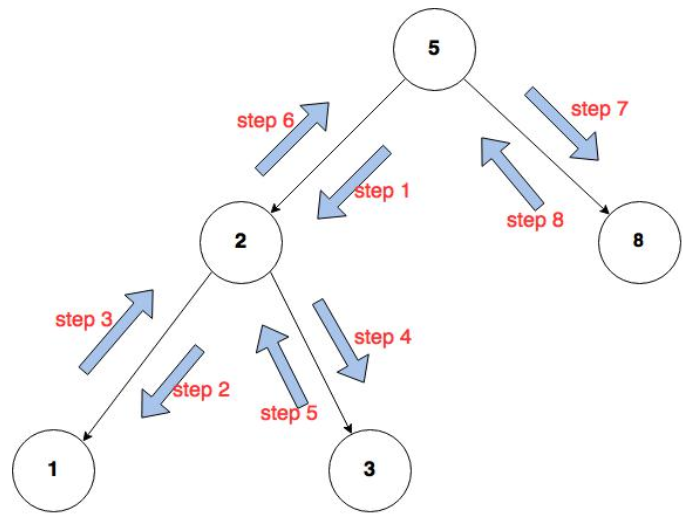

What we need to know?

- The Direction!
- Are we visiting down, or returning from left, or returning from right?

The root is the top element in the stack.

**Maintain a previous Node** to record the previous visiting node on the traversing path, so that we know what the direction we are taking now and what is the direction we are taking next.

- root = stack.top
- if previous is null, then going down (left subtree has priority)
- if previous is current’s parent, then going down (left subtree has priority)
- if previous == current.left, then left subtree finished, going current.right
- if previous == current.right, then right subtree finished, pop current, going up

```java
public void postOrder(TreeNode root) {
  // 1. Initial check
  if (root == null) {
    return;
  }
  // 2. Local variables
  Deque<TreeNode> stack = new LinkedList<>();
  TreeNode prev = null;
  stack.offerFirst(root);

  // 3.
  while (!stack.isEmpty()) {
    TreeNode curr = stack.peekFirst();
    // Going down
    if (prev == null || curr == prev.left || curr == prev.right) {
      if (curr.left != null) {
        stack.offerFirst(curr.left);
      }
      else if (curr.right != null) {
        stack.offerFirst(curr.right);
      }
      else {
        System.out.println(curr.value);
        stack.pollFirst();
      }
    }
    // From left subtree
    else if (prev == curr.left) {
      if (curr.right != null) {
        stack.offerFirst(curr.right);
      }
      else {
        System.out.println(curr.value);
        stack.pollFirst();
      }
    }
    // From right subtree
    else {
      System.out.println(curr.value);
      stack.pollFirst();
    }
    prev = curr;
  }
}
```

```
    5
   / \
  2   8
 / \
1   3

Previous        Stack        Print (left and right subtree both finished)
null            {5}
5               {5, 2}
2               {5, 2, 1}    1
1               {5, 2}
2               {5, 2, 3}    3
3               {5, 2}       2
2               {5}
5               {5, 8}       8
8               {5}          5
5               {}
```

This solution is **important** because this is the closest imitation of how actually the recursion is done in STACK, and it can be used as a general framework to iteratively do pre-order and in-order traversal as well.

**If you look closely, the recursion is actually a DFS procedure on the binary tree. Pre-order, in-order, post-order are following the same DFS procedure, and the only difference is then you want to print the node.**